# Final Project Report - Pandemic Vaccine Analysis

Jiani Wang

2024-12-16

# Introduction

## Description of the data set

- The dataset is a mock dataset from a clincal trial on pandemic influenza vaccines.
- The dataset include participant-level information on immunogenicity, reactogenicity, and varying demographics, along with details on different vaccine formulations, antigens, and adjuvants.
- The cleaned data set with all missing values removed contains 202 observations and 16 variables.

## Analysis objectives

- Explore the associations between immunogenicity and reactogenicity across gender and ethnicity.
- The exposure would be reactogenicity (reaction scores). The outcome would be immunogeicity (log transformed HAI titers).

# Descriptive Statistics

## Table Summary

Characteristics of the 202 participants from the pandemic vaccine data set are displayed in the table below.

```r
descriptive_stats_table <- readRDS(
  file = here::here("output/descriptive_stats_table.rds")
)
descriptive_stats_table
```

| **Characteristic** | **Overall** N = 202<sup>1</sup> | **F** N = 124<sup>1</sup> | **M** N = 78<sup>1</sup> |
| --- | --- | --- | --- |
| AGE | 54 (17) | 53 (16) | 55 (18) |
| ETHNICITY |  |  |  |
| American Indian/Alaskan | 3 (1.5%) | 2 (1.6%) | 1 (1.3%) |
| Asian | 12 (5.9%) | 6 (4.8%) | 6 (7.7%) |
| Black/African Amer | 5 (2.5%) | 2 (1.6%) | 3 (3.8%) |
| Hispanic/Latino | 5 (2.5%) | 3 (2.4%) | 2 (2.6%) |
| White | 177 (88%) | 111 (90%) | 66 (85%) |
| BMI | 27.2 (5.8) | 26.7 (6.3) | 27.8 (4.8) |
| log_hai_titer | 2.41 (0.95) | 2.37 (0.96) | 2.46 (0.95) |
| reaction_scores | 4 (1) | 4 (1) | 4 (1) |
| antigen |  |  |  |
| B/Victoria | 77 (38%) | 52 (42%) | 25 (32%) |
| H1N1 | 71 (35%) | 41 (33%) | 30 (38%) |
| H3N2 | 54 (27%) | 31 (25%) | 23 (29%) |
| adjuvant |  |  |  |
| AS03 | 68 (34%) | 41 (33%) | 27 (35%) |
| MF59 | 59 (29%) | 33 (27%) | 26 (33%) |
| None | 75 (37%) | 50 (40%) | 25 (32%) |

<sup>1</sup> Mean (SD); n (%)

- The average age of participants is 54 years, with a slightly younger mean age for females (53 years) compared to males (55 years).
- The majority of participants identify as White (88%), followed by smaller proportions of Asian (5.9%), Black/African American (2.5%), and Hispanic/Latino (2.5%).
- Log-transformed HAI titers are marginally higher for males (2.46) than females (2.37).
- The mean reaction score is 3.69 overall, with males showing slightly higher scores (3.78) than females (3.64).

## Scatterplot of Overall Relationship Between Reaction Scores and Log HAI Titers

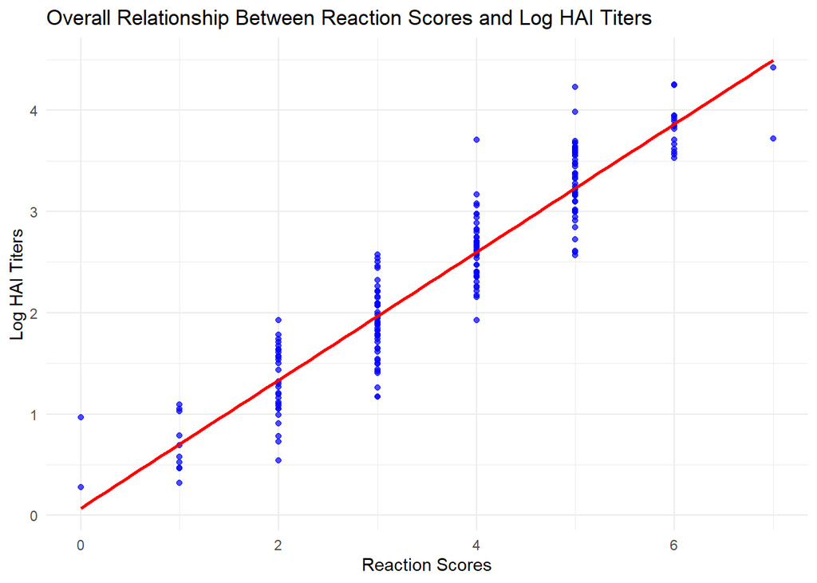

From this scatterplot, we can directly see a positive relationship between reaction scores and log HAI titers.

## Scatterplot stratified by GENDER

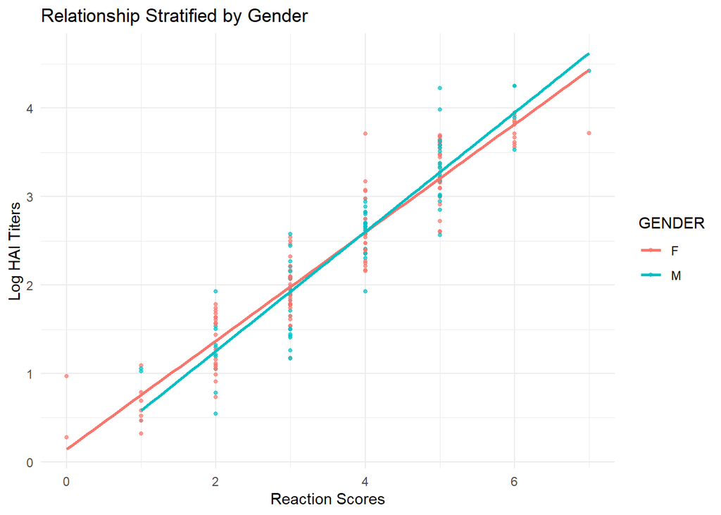

The scatterplot stratified by gender shows a generally positive relationship between reaction scores and log HAI titers for both males (blue) and females (red). Males tend to have a slightly steeper slope compared to females, suggesting that for the same increase in reaction scores, log HAI titers tend to be somewhat higher in males.

## Scatterplot stratified by ETHNICITY

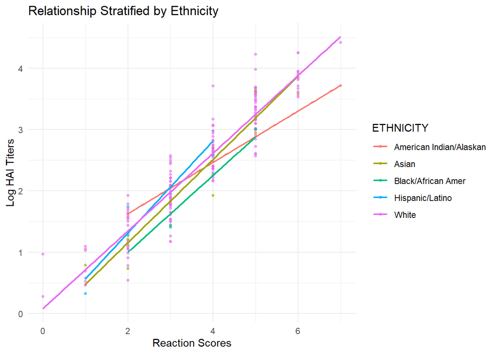

# Modeling

## Model Fitting

```
##
## Call:
## lm(formula = log_hai_titer ~ reaction_scores * GENDER * ETHNICITY,
##     data = clean_data)
##
## Coefficients:
##                                         (Intercept)
##                                             0.76570
##                                     reaction_scores
##                                             0.42185
##                                             GENDERM
##                                            -0.12346
##                                      ETHNICITYAsian
##                                            -0.94405
##                         ETHNICITYBlack/African Amer
##                                            -0.49247
##                            ETHNICITYHispanic/Latino
##                                            -1.05555
##                                      ETHNICITYWhite
##                                            -0.61350
##                             reaction_scores:GENDERM
##                                             0.05465
##                      reaction_scores:ETHNICITYAsian
##                                             0.25856
##         reaction_scores:ETHNICITYBlack/African Amer
##                                             0.07616
##            reaction_scores:ETHNICITYHispanic/Latino
##                                             0.39170
##                      reaction_scores:ETHNICITYWhite
##                                             0.19275
##                              GENDERM:ETHNICITYAsian
##                                             0.03872
##                 GENDERM:ETHNICITYBlack/African Amer
##                                            -1.10398
##                    GENDERM:ETHNICITYHispanic/Latino
##                                            -0.27457
##                              GENDERM:ETHNICITYWhite
##                                            -0.08168
##              reaction_scores:GENDERM:ETHNICITYAsian
##                                            -0.04724
## reaction_scores:GENDERM:ETHNICITYBlack/African Amer
##                                             0.23998
##    reaction_scores:GENDERM:ETHNICITYHispanic/Latino
##                                                  NA
##              reaction_scores:GENDERM:ETHNICITYWhite
##                                                  NA
```

## Key Summary

```
## # A tibble: 4 × 5
##   term                           estimate std.error   p.value signif
##   <chr>                             <dbl>     <dbl>     <dbl> <chr>
## 1 reaction_scores                   0.422    0.0954 0.0000167 ***
## 2 ETHNICITYAsian                   -0.944    0.571  0.0997    .
## 3 reaction_scores:ETHNICITYAsian    0.259    0.122  0.0360    *
## 4 reaction_scores:ETHNICITYWhite    0.193    0.0981 0.0510    .
```

A statistically significant positive relationship exists between reaction_scores and log_hai_titer (estimate = 0.42, p < 0.001).This suggests that higher reaction scores are associated with higher log-transformed HAI titers.The significant positive interaction term (estimate = 0.26, p = 0.036) implies that for Asian participants, the relationship between reaction scores and log HAI titers becomes stronger compared to the baseline. The interaction for White ethnicity is borderline significant (estimate = 0.19, p = 0.051). This suggests a potential influence of ethnicity in modulating the relationship.